# Corona - Tagesreport

## Infos zum Bericht

### Abrufzeitpunkt

| Amtliche RKI-Corona-Daten für Land-/Stadtkreis | Abrufzeitpunkt |
| --- | --- |
| Kreisfreie Stadt Passau | Donnerstag, 29.04.2021, 05:26:20 |

### Inzidenzrelevanter Zeitraum

| von - bis | nicht mehr in der Inzidenzzahl |
| --- | --- |
| Do, 22.04.2021 - Mi, 28.04.2021 | Mi, 21.04.2021 und älter |

### Datenbeschreibung

[Link zur Datenbeschreibung des RKI](https://www.arcgis.com/home/item.html?id=dd4580c810204019a7b8eb3e0b329dd6)

## Diagramme

### Wochenübersicht

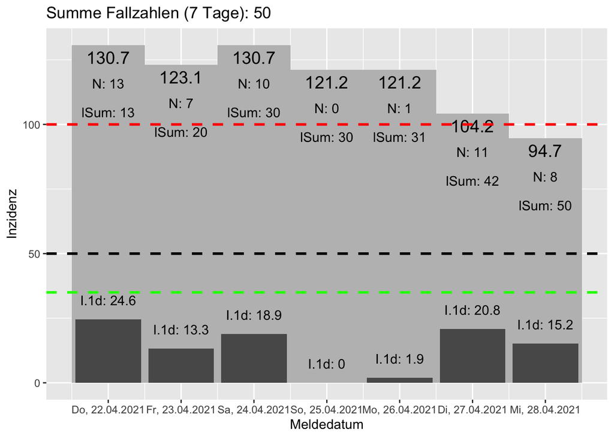

Erläuterung der Zahlenangaben:  
**N**: Anzahl der neu und nachträglich gemeldeten abzüglich der gestrichenen Fälle des jeweiligen Tages  
**I.1d** (“1-Tages-Inzidenz”): Höhe des Beitrags, den dieser Tag zur Wocheninzidenz leistet  
**lSum**: Aggregierte Summe der Fallzahlen über den Verlauf der beobachteten Woche. Der erste Tag entspricht diesem einzelnen Tag (und fällt als nächstes aus der Inzidenz), der letzte Tag entspricht der Wochen-Inzidenz.

### Neu gemeldete Fälle je Tag seit 01.01.2021

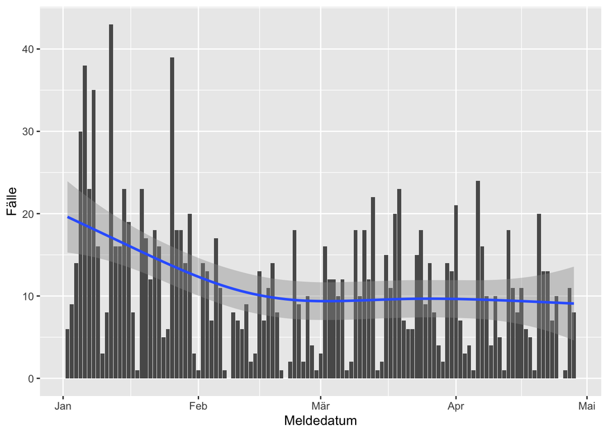

## Details zu Inzidenz und Altersstruktur

### Heute neu

| Meldedatum | Art | Inzidenzrelevant | Fallzahl | A00-A04 | A05-A14 | A15-A34 | A35-A59 | A60-A79 |
| --- | --- | --- | --- | --- | --- | --- | --- | --- |
| 2021-04-28 | Neu | Ja | 8 | 2 | 1 | 3 | 1 | 1 |

### Altersstruktur

“Kohorteninzidenz” steht für die getrennt nach Altersgruppen (“Kohorten”) ausgewiesene 7-Tage-Inzidenz. Diese wird von RKI bislang nicht veröffentlicht, da hierfür die lokale Altersstruktur bekannt sein muss.

|  | A00-A04 | A05-A14 | A15-A34 | A35-A59 | A60-A79 | A80+ |
| --- | --- | --- | --- | --- | --- | --- |
| Fälle | 3 | 4 | 24 | 14 | 4 | 1 |
| EWO | 2138 | 3180 | 15820 | 16601 | 11298 | 3744 |
| Kohorteninzidenz | 140.3 | 125.8 | 151.7 | 84.3 | 35.4 | 26.7 |

### Grenzwerte

| Grenzwert | max. Fälle | Abweichung |
| --- | --- | --- |
| 35 | 18 | +32 |
| 50 | 26 | +24 |
| 100 | 52 | -2 |

### Nächste 3 Streichungen

Aktuelle Inzidenz: 94.7, basierend auf den insgesamt 50 Fällen der letzten Woche.

| Stichtag | Streichtag | kum. Fallzahl | kum. Inzidenz | max. Rückgang auf |
| --- | --- | --- | --- | --- |
| Morgen | 22.04.2021 | -13 | -24.6 | 70.1 |
| Übermorgen | 23.04.2021 | -20 | -13.3 | 56.8 |
| In drei Tagen | 24.04.2021 | -30 | -18.9 | 37.9 |

Die Fallzahlen der nächsten Tage sowie eventuelle Nachmeldungen sind dabei nicht vorhersehbar. Der maximale Rückgang wird nur erreicht, wenn bis zu diesem Tag per Saldo kein neuer Fall erfasst wird.

### Rückblick (3w)

Fallzahlen gehen je nach Wochentag in unterschiedlicher Höhe ein. Basierend auf den letzten 3 Wochen bzw. 21 Tagen ergibt sich folgende Verteilung:

| Wochentag | Mittelwert |
| --- | --- |
| Sonntag | 3.33 |
| Montag | 1.00 |
| Dienstag | 16.33 |
| Mittwoch | 10.67 |
| Donnerstag | 10.33 |
| Freitag | 7.33 |
| Samstag | 8.67 |

…auf der Grundlage folgender Fallzahlen der letzten 3 Wochen:

| Meldedatum | Fälle | Wochentag |
| --- | --- | --- |
| 2021-04-08 | 10 | Donnerstag |
| 2021-04-09 | 4 | Freitag |
| 2021-04-10 | 10 | Samstag |
| 2021-04-11 | 5 | Sonntag |
| 2021-04-12 | 1 | Montag |
| 2021-04-13 | 18 | Dienstag |
| 2021-04-14 | 11 | Mittwoch |
| 2021-04-15 | 8 | Donnerstag |
| 2021-04-16 | 11 | Freitag |
| 2021-04-17 | 6 | Samstag |
| 2021-04-18 | 5 | Sonntag |
| 2021-04-19 | 1 | Montag |
| 2021-04-20 | 20 | Dienstag |
| 2021-04-21 | 13 | Mittwoch |
| 2021-04-22 | 13 | Donnerstag |
| 2021-04-23 | 7 | Freitag |
| 2021-04-24 | 10 | Samstag |
| 2021-04-25 | 0 | Sonntag |
| 2021-04-26 | 1 | Montag |
| 2021-04-27 | 11 | Dienstag |
| 2021-04-28 | 8 | Mittwoch |

## Blick in die Kristallkugel

Hier werden drei verschiedene Szenarien dargestellt:  
* Optimistische Variante 0 (Grün): Es treten keine Fälle mehr auf, somit dauert es noch 7 Tage, bis alle Inzidenzfälle abgeschmolzen sind.  
* Realistische Variante 1 (schwarz): Täglich kommen die durchschnittlichen Fälle für den jeweiligen Wochentag hinzu, was dem Abschmelzen aus Variante 0 entgegenwirkt.  
* Pessimistische Variante 2 (Rot): Wie Variante 1, nur kommt täglich der DOPPELTE Durchschnitt für den jeweiligen Wochentag hinzu. Dieser Zuwachs stellt keineswegs das obere Limit des möglichen dar.

**Bitte beachten: Im Folgenden stellt die Zeitachse das Veröffentlichungsdatum dar, nicht das Meldedatum, und ist somit um einen Tag verschoben!**

### Prognose der Inzidenzen

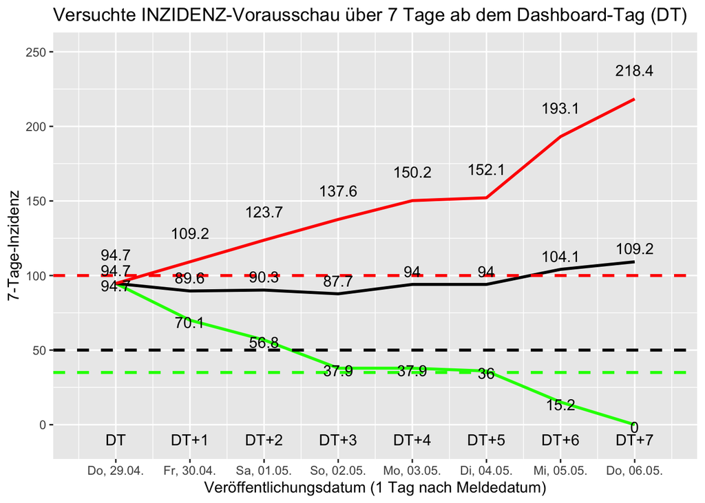

### Prognose der Fallzahlen

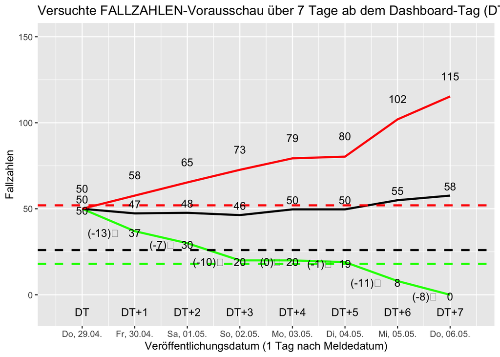